# Understanding Bike Lyft Usage Behaviors - Ford GoBike System

## Investigation Overview

> In this presentation, I want to understad users usage trends for Bike Lyft service in 2018.

## Dataset Overview

> This document explores a dataset about Lyft bay wheels service which contains 1863721 trip data for the year 2018.

Each trip is anonymized and includes:

- Trip Duration (seconds)
- Start Time and Date
- End Time and Date
- Start Station ID
- Start Station Name
- Start Station Latitude
- Start Station Longitude
- End Station ID
- End Station Name
- End Station Latitude
- End Station Longitude
- Bike ID
- User Type (Subscriber or Customer – “Subscriber” = Member or “Customer” = Casual)

```python
# import all packages and set plots to be embedded inline
import numpy as np
import pandas as pd
import matplotlib.pyplot as plt
import seaborn as sb

%matplotlib inline

# suppress warnings from final output
import warnings
warnings.simplefilter("ignore")
```

```python
# load in the dataset into a pandas dataframe
df_clean = pd.read_csv('ford_bike_master.csv')
```

## (Visualization 1)

> **What is the distribution of users types in Lyft Bike data?**

```
Text(0.5,0,'User Type')
```

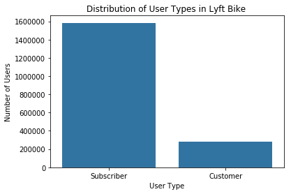

```python
base_color = sb.color_palette()[0]
ax = sb.countplot(data = df_clean, x = 'user_type', color = base_color)
ax.set_title('Distribution of User Types in Lyft Bike ')
ax.set_ylabel('Number of Users')
ax.set_xlabel('User Type')
```

## (Visualization 2)

> **How Customer and Subscribers use Bike Lyft service during the weeks in 2018?**

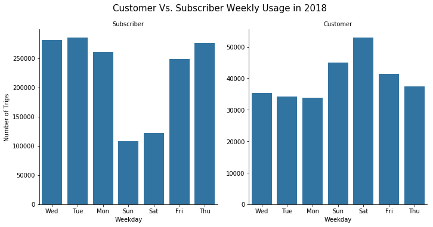

```python
g = sb.catplot(data=df_clean, x='day', col="user_type", kind='count', sharey = False,
            color = base_color)
g.fig.suptitle('Customer Vs. Subscriber Weekly Usage in 2018 ', fontsize=15,y=1.05)
g.set_titles("{col_name}")
g.set_axis_labels(x_var="Weekday", y_var="Number of Trips")
```

> **Subscribers** appear to use the service more in week days, and they have higher number of trips compared to customers.

## (Visualization 3)

**How does the average trip duration vary between user the based on the day of the week?**

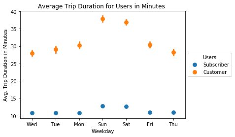

```python
df_clean['duration_min'] = df_clean['duration_sec'] /60
ax = sb.pointplot(x="day", y="duration_min", hue="user_type",data=df_clean,linestyles="")
plt.xlabel('Weekday');
plt.title('Average Trip Duration for Users in Minutes ')
plt.ylabel('Avg. Trip Duration in Minutes');
ax.legend(title='Users',loc='center left', bbox_to_anchor=(1, 0.5))
```

**Customers seems to take longer trips compared to Subscribers in terms of average minutes.**